# STI Analysis Assignment

Author

Kamau Nthoki

# 1. Cleaning the data

```r
##working directory
require(haven)
setwd("C:/Users/Lilly Kamau/Desktop/RStudio")
getwd()
```

```
[1] "C:/Users/Lilly Kamau/Desktop/RStudio"
```

```r
list.files()
```

```
 [1] "~$ARTO R ASSIGNMENT.docx"
 [2] "AMREC R Course-20250721T040429Z-1-001.zip"
 [3] "chrome_100_percent.pak"
 [4] "chrome_200_percent.pak"
 [5] "d3dcompiler_47.dll"
 [6] "ffmpeg.dll"
 [7] "icudtl.dat"
 [8] "libEGL.dll"
 [9] "libGLESv2.dll"
[10] "LICENSE"
[11] "LICENSES.chromium.html"
[12] "locales"
[13] "QUARTO R ASSIGNMENT.docx"
[14] "R training"
[15] "resources"
```

[output cut: 22 more lines]

```r
stidata<-read.csv("STIData.csv")
```

```r
##cleaning data
summary(stidata)
```

```
    IdNumber       CaseStatus        Date               A1Age
 Min.   :  1.0   Min.   :1.000   Length:227         Min.   :16.00
 1st Qu.: 56.5   1st Qu.:1.000   Class :character   1st Qu.:23.00
 Median :113.0   Median :2.000   Mode  :character   Median :26.00
 Mean   :113.2   Mean   :1.515                      Mean   :28.04
 3rd Qu.:169.5   3rd Qu.:2.000                      3rd Qu.:32.00
 Max.   :226.0   Max.   :3.000                      Max.   :63.00

 A2Occupation         A3Church         A4LevelOfEducation A5MaritalStatus
 Length:227         Length:227         Length:227         Length:227
 Class :character   Class :character   Class :character   Class :character
 Mode  :character   Mode  :character   Mode  :character   Mode  :character




     Weight           Height        C3StiYesno     D1BurialSociety
 Min.   : 32.80   Min.   :138.0   Min.   :0.0000   Min.   :1.000
 1st Qu.: 45.50   1st Qu.:156.0   1st Qu.:0.0000   1st Qu.:1.000
 Median : 51.00   Median :160.0   Median :0.0000   Median :2.000
 Mean   : 53.75   Mean   :160.9   Mean   :0.1534   Mean   :1.661
 3rd Qu.: 60.75   3rd Qu.:166.0   3rd Qu.:0.0000   3rd Qu.:2.000
 Max.   :100.00   Max.   :191.0   Max.   :1.0000   Max.   :2.000
                  NA's   :1       NA's   :64
 D1religiousgrp  D1savingsClub  D1tradersAssoc    D2Group1
 Min.   :1.000   Min.   :1.00   Min.   :1.000   Length:227
 1st Qu.:1.000   1st Qu.:1.00   1st Qu.:2.000   Class :character
 Median :1.000   Median :2.00   Median :2.000   Mode  :character
 Mean   :1.449   Mean   :1.73   Mean   :1.947
 3rd Qu.:2.000   3rd Qu.:2.00   3rd Qu.:2.000
 Max.   :2.000   Max.   :2.00   Max.   :2.000
                 NA's   :1
   D2Group2          D3Education    D3FuneralAssistance D3HealthServices
 Length:227         Min.   :1.000   Min.   :1.00        Min.   :1.000
 Class :character   1st Qu.:2.000   1st Qu.:1.00        1st Qu.:1.000
 Mode  :character   Median :2.000   Median :1.00        Median :2.000
                    Mean   :1.791   Mean   :1.08        Mean   :1.652
                    3rd Qu.:2.000   3rd Qu.:1.00        3rd Qu.:2.000
                    Max.   :2.000   Max.   :2.00        Max.   :2.000
                    NA's   :64      NA's   :64          NA's   :63
```

[output cut: 40 more lines]

```
 SexPartner1year  SexPartner3month  LastPartnerSpouse     Belong
 Min.   :0.0000   Min.   :0.00000   Min.   :0.0000    Min.   :0.0000
 1st Qu.:0.0000   1st Qu.:0.00000   1st Qu.:0.0000    1st Qu.:0.0000
 Median :0.0000   Median :0.00000   Median :1.0000    Median :1.0000
 Mean   :0.2291   Mean   :0.09692   Mean   :0.6916    Mean   :0.7004
 3rd Qu.:0.0000   3rd Qu.:0.00000   3rd Qu.:1.0000    3rd Qu.:1.0000
 Max.   :1.0000   Max.   :1.00000   Max.   :1.0000    Max.   :1.0000

  ReceiveHelp     SexPartnerLife3     Sex.1
 Min.   :0.0000   Min.   :0.0000   Length:227
 1st Qu.:0.0000   1st Qu.:0.0000   Class :character
 Median :1.0000   Median :0.0000   Mode  :character
 Mean   :0.6872   Mean   :0.4053
 3rd Qu.:1.0000   3rd Qu.:1.0000
 Max.   :1.0000   Max.   :1.0000
```

```r
##checking for missing values
colSums(is.na(stidata))
```

```
            IdNumber           CaseStatus                 Date
                   0                    0                    0
               A1Age         A2Occupation             A3Church
                   0                    0                    0
  A4LevelOfEducation      A5MaritalStatus               Weight
                   0                    0                    0
              Height           C3StiYesno      D1BurialSociety
                   1                   64                    0
      D1religiousgrp        D1savingsClub       D1tradersAssoc
                   0                    1                    0
            D2Group1             D2Group2          D3Education
                   0                    0                   64
 D3FuneralAssistance     D3HealthServices    DurationOfillness
                  64                   63                   86
        E8WhyhaveSTI N10givereceiveforsex        N11Usedcondom
                   0                    0                    0
        N12UseCondom      N13TakenAlcohol         N14DoYouHave
                   0                    0                    0
   N15LivingTogether          N16HowOldIs      D3receivecredit
                  35                   35                   64
           Typeofsti           N2SexDebut           N3HadAnSti
                   0                    6                    2
      N9Relationship                  Sex          AgeFirstSex
                   0                    0                    0
    HabitationStatus           Unemployed            Education
                   0                   14                    0
          AlcoholUse      SexPartner1year     SexPartner3month
                   2                    0                    0
   LastPartnerSpouse               Belong          ReceiveHelp
                   0                    0                    0
     SexPartnerLife3                Sex.1
                   0                    0
```

```r
sum(is.na(stidata$Height ))
```

```
[1] 1
```

```r
stidata <- stidata[!is.na(stidata$Height ), ]
# Replacing missing heights with the median height
summary(stidata$Height )
```

```
   Min. 1st Qu.  Median    Mean 3rd Qu.    Max.
  138.0   156.0   160.0   160.9   166.0   191.0
```

```r
stidata$Height [is.na(stidata$Height )] <- 160
```

```r
##checking for duplicates
dups=duplicated(stidata$IdNumber)
stidata$IdNumber[duplicated(stidata$IdNumber)]
```

```
[1] 51
```

```r
View(stidata[stidata$IdNumber==51,])
stidata<-stidata[!(stidata$IdNumber==51 & stidata$A1Age==23),]
View(stidata[stidata$IdNumber==51,])
```

```r
##checking for inconsistencies
summary(stidata)
```

```
    IdNumber       CaseStatus       Date               A1Age
 Min.   :  1.0   Min.   :1.00   Length:225         Min.   :16.00
 1st Qu.: 57.0   1st Qu.:1.00   Class :character   1st Qu.:23.00
 Median :113.0   Median :2.00   Mode  :character   Median :26.00
 Mean   :113.2   Mean   :1.52                      Mean   :28.04
 3rd Qu.:169.0   3rd Qu.:2.00                      3rd Qu.:32.00
 Max.   :226.0   Max.   :3.00                      Max.   :63.00

 A2Occupation         A3Church         A4LevelOfEducation A5MaritalStatus
 Length:225         Length:225         Length:225         Length:225
 Class :character   Class :character   Class :character   Class :character
 Mode  :character   Mode  :character   Mode  :character   Mode  :character




     Weight           Height      C3StiYesno     D1BurialSociety
 Min.   : 32.80   Min.   :138   Min.   :0.0000   Min.   :1.000
 1st Qu.: 45.50   1st Qu.:156   1st Qu.:0.0000   1st Qu.:1.000
 Median : 51.00   Median :160   Median :0.0000   Median :2.000
 Mean   : 53.72   Mean   :161   Mean   :0.1543   Mean   :1.658
 3rd Qu.: 61.00   3rd Qu.:166   3rd Qu.:0.0000   3rd Qu.:2.000
 Max.   :100.00   Max.   :191   Max.   :1.0000   Max.   :2.000
                                NA's   :63
 D1religiousgrp  D1savingsClub   D1tradersAssoc    D2Group1
 Min.   :1.000   Min.   :1.000   Min.   :1.000   Length:225
 1st Qu.:1.000   1st Qu.:1.000   1st Qu.:2.000   Class :character
 Median :1.000   Median :2.000   Median :2.000   Mode  :character
 Mean   :1.453   Mean   :1.728   Mean   :1.947
 3rd Qu.:2.000   3rd Qu.:2.000   3rd Qu.:2.000
 Max.   :2.000   Max.   :2.000   Max.   :2.000
                 NA's   :1
   D2Group2          D3Education    D3FuneralAssistance D3HealthServices
 Length:225         Min.   :1.000   Min.   :1.000       Min.   :1.000
 Class :character   1st Qu.:2.000   1st Qu.:1.000       1st Qu.:1.000
 Mode  :character   Median :2.000   Median :1.000       Median :2.000
                    Mean   :1.789   Mean   :1.081       Mean   :1.648
                    3rd Qu.:2.000   3rd Qu.:1.000       3rd Qu.:2.000
                    Max.   :2.000   Max.   :2.000       Max.   :2.000
                    NA's   :64      NA's   :64          NA's   :63
```

[output cut: 40 more lines]

```
 SexPartner3month  LastPartnerSpouse     Belong        ReceiveHelp
 Min.   :0.00000   Min.   :0.0000    Min.   :0.0000   Min.   :0.0000
 1st Qu.:0.00000   1st Qu.:0.0000    1st Qu.:0.0000   1st Qu.:0.0000
 Median :0.00000   Median :1.0000    Median :1.0000   Median :1.0000
 Mean   :0.09333   Mean   :0.6933    Mean   :0.6978   Mean   :0.6844
 3rd Qu.:0.00000   3rd Qu.:1.0000    3rd Qu.:1.0000   3rd Qu.:1.0000
 Max.   :1.00000   Max.   :1.0000    Max.   :1.0000   Max.   :1.0000

 SexPartnerLife3     Sex.1
 Min.   :0.0000   Length:225
 1st Qu.:0.0000   Class :character
 Median :0.0000   Mode  :character
 Mean   :0.4044
 3rd Qu.:1.0000
 Max.   :1.0000
```

```r
str(stidata)
```

```
'data.frame':   225 obs. of  47 variables:
 $ IdNumber            : int  32 33 34 35 10 11 12 13 14 15 ...
 $ CaseStatus          : int  2 1 2 1 2 1 2 1 2 1 ...
 $ Date                : chr  "03-Dec-09" "03-Dec-09" "03-Dec-09" "03-Dec-09" ...
 $ A1Age               : int  23 24 24 33 63 22 22 19 22 29 ...
 $ A2Occupation        : chr  "1 unemployed" "4 student" "1 unemployed" "3 formal" ...
 $ A3Church            : chr  "5 pentecostal" "2 apostolic" "2 apostolic" "7 roman catholic" ...
 $ A4LevelOfEducation  : chr  "3 secondary" "3 secondary" "3 secondary" "3 secondary" ...
 $ A5MaritalStatus     : chr  "2 married" "2 married" "2 married" "2 married" ...
 $ Weight              : num  61 53 91.4 100 83 74.5 94 82 38 73.5 ...
 $ Height              : num  182 166 166 166 156 154 170 158 168 160 ...
 $ C3StiYesno          : int  NA 0 0 NA 0 0 NA NA 0 1 ...
 $ D1BurialSociety     : int  2 2 2 1 1 2 2 1 1 1 ...
 $ D1religiousgrp      : int  1 2 1 2 1 2 2 1 1 2 ...
 $ D1savingsClub       : int  2 2 2 2 2 2 2 2 1 1 ...
```

[output cut: 33 more lines]

```r
table(stidata$Sex )
```

```
       Female   Male
     2    107    116
```

```r
for (col in names(stidata)) {
  cat("Unique values in", col, ":\n")
  print(unique(stidata[[col]]))
  cat("\n-----------------------\n")
}
```

```
Unique values in IdNumber :
  [1]  32  33  34  35  10  11  12  13  14  15  16  17  18  19   6   7   8   9
 [19]  20  21  22  23  24  25  26  27  28  29  30  31  36  37  38  39  40  41
 [37]  42  43  44  45  46  47  48  49  50  51  52  53  54  55  85  86  87  88
 [55]  89  90  91  92  93  94  95  96  97  98  99 100 101 102 103 104 105 106
 [73] 107 108 109 110 111 112 113 114 115 116 117 118 119 120 121 122 123 124
 [91] 125 126 127 128 129 130 131 132 133 134 135 136 137 138 139 140 141 142
[109] 143 144 145 146 147 148 149 150 151 152 153 154 155 156 157 158 159 160
[127] 161 162   1   2   3   4   5  56  57  58  59  60  61  62  63  64  65  66
[145]  67  68  69  70  71  72  73  74  75  76  77  78  79  80  81  82  83  84
[163] 163 164 165 166 167 168 169 170 171 172 173 174 175 176 177 178 179 180
[181] 181 182 183 184 185 186 188 189 190 191 192 193 194 195 196 197 198 199
[199] 200 201 202 203 204 205 206 207 208 209 210 211 212 213 214 215 216 217
[217] 218 219 220 221 222 223 224 225 226

-----------------------
Unique values in CaseStatus :
[1] 2 1 3

-----------------------
Unique values in Date :
[1] "03-Dec-09" "04-Dec-09" "05-Dec-09" "06-Dec-09" "08-Dec-09" "08-Dec-08"

-----------------------
Unique values in A1Age :
 [1] 23 24 33 63 22 19 29 21 26 25 30 36 31 48 43 16 32 27 28 20 38 45 42 34 39
[26] 35 41 37 40 18 46 50 44 17

-----------------------
Unique values in A2Occupation :
[1] "1 unemployed" "4 student"    "3 formal"     "2 informal"

-----------------------
Unique values in A3Church :
[1] "5 pentecostal"    "2 apostolic"      "7 roman catholic" "8 other"
[5] "6 atheist"        "3 methodist"      "4 anglican"

-----------------------
Unique values in A4LevelOfEducation :
[1] "3 secondary" "2 primary"   "4 tertiary"  "1 none"
```

[output cut: 166 more lines]

```
[1] 1 0

-----------------------
Unique values in ReceiveHelp :
[1] 1 0

-----------------------
Unique values in SexPartnerLife3 :
[1] 0 1

-----------------------
Unique values in Sex.1 :
[1] "Female" "Male"

-----------------------
```

```r
stidata$N11Usedcondom <- tolower(stidata$N11Usedcondom)
stidata$N12UseCondom  <- tolower(stidata$N12UseCondom)
stidata$N13TakenAlcohol <- tolower(stidata$N13TakenAlcohol)
stidata$N10givereceiveforsex <- tolower(stidata$N10givereceiveforsex)
stidata$Sex <- tolower(stidata$Sex)

stidata$Sex <- trimws(stidata$Sex)
table(stidata$Height)
```

```
138 143 145 146 147 148 149 150 151 152 153 154 155 156 157 158 159 160 161 162
  1   1   4   1   1   5   4   6   3   6   2   8  10   9  16  14   7  15   9   9
163 164 165 166 167 168 169 170 171 172 173 174 175 176 177 180 182 191
 13  11   7   9   9  13   4   8   3   1   2   3   2   1   2   2   3   1
```

```r
##creating categorical variables
#Agecategory
dim(stidata)
```

```
[1] 225  47
```

```r
stidata$AgeCat<-NA
stidata$AgeCat[stidata$A1Age >= 16 & stidata$A1Age <= 34] <- 1
stidata$AgeCat[stidata$A1Age >= 35 & stidata$A1Age <= 64] <- 0
stidata$AgeCat <- factor(stidata$AgeCat, levels = c(1, 0), labels = c("16–34 yrs", "35–64 yrs"))
table(stidata$AgeCat)
```

```
16–34 yrs 35–64 yrs
      193        32
```

```r
#creating BMI
stidata$BMI <- stidata$Weight / ((stidata$Height / 100)^2)
stidata$BMI <- cut(stidata$BMI,
                       breaks = c(0, 18.5, 24.9, 29.9, 34.9, Inf),
                       labels = c("Underweight", "Normal", "Overweight", "Obese Class I", "Obese Class II+"),
                       right = TRUE)
summary(stidata$BMI)
```

```
    Underweight          Normal      Overweight   Obese Class I Obese Class II+
             92              97              28               7               1
```

```r
#Creating occupation
stidata$Occupation<-NA
stidata$Occupation[stidata$A2Occupation =="1 unemployed"|
                     stidata$A2Occupation == "4 student"]=1
stidata$Occupation[stidata$A2Occupation =="2 informal"|
                     stidata$A2Occupation =="3 formal"]=0
stidata$Occupation<-factor(stidata$Occupation, levels = c(1,0),labels = c("Unemployed", "Employed"))
summary(stidata$Occupation)
```

```
Unemployed   Employed
        90        135
```

```r
#creating churuch
class(stidata)
```

```
[1] "data.frame"
```

```r
table(stidata$A3Church)
```

```
     2 apostolic      3 methodist       4 anglican    5 pentecostal
              52               13               16               35
       6 atheist 7 roman catholic          8 other
              45               41               23
```

```r
stidata$Religion<-NA
stidata$Religion[stidata$A3Church=="7 roman catholic"|
                   stidata$A3Church=="2 apostolic"|
                   stidata$A3Church=="3 methodist"|
                   stidata$A3Church=="4 anglican"|
                   stidata$A3Church=="5 pentecostal"]=1
stidata$Religion[ stidata$A3Church=="6 atheist"|
                    stidata$A3Church=="8 other"]=0

stidata$Religion<-factor(stidata$Religion, levels = c(1,0),labels = c("Belivers", "Non-Belivers"))
table(stidata$Religion)
```

```
    Belivers Non-Belivers
         157           68
```

```r
##creating marital status
table(stidata$A5MaritalStatus)
```

```
     1 single     2 married 3 co-habiting    4 divorcee     5 widowed
           43           148             9            16             9
```

```r
class(stidata$A5MaritalStatus)
```

```
[1] "character"
```

```r
stidata$Marital_status<-NA
stidata$Marital_status[stidata$A5MaritalStatus=="2 married"]=1
stidata$Marital_status[stidata$Marital_status=="1 single"|
                                 stidata$A5MaritalStatus=="5 widowed"|
                                 stidata$A5MaritalStatus=="3 co-habiting"|
                                 stidata$A5MaritalStatus=="4 divorcee"]=0

stidata$Marital_status<-factor(stidata$Marital_status, levels = c(1,0),
                                       labels = c("Married", "Single"))
table(stidata$Marital_status)
```

```
Married  Single
    148      34
```

```r
##creating education level
table(stidata$A4LevelOfEducation)
```

```
     1 none   2 primary 3 secondary  4 tertiary
          1          26         187          11
```

```r
class(stidata$A4LevelOfEducation)
```

```
[1] "character"
```

```r
stidata$education_level<-NA
stidata$education_level[stidata$A4LevelOfEducation=="1 none"|
                                stidata$A4LevelOfEducation=="2 primary"]=1;
stidata$education_level[
  stidata$A4LevelOfEducation=="3 secondary"|
    stidata$A4LevelOfEducation=="4 tertiary"]=0;

stidata$education_level<-factor(stidata$education_level,
                                      levels = c(1,0),
                                      labels = c("Primary & Below","Secondary & Above"))
table(stidata$education_level)
```

```
  Primary & Below Secondary & Above
               27               198
```

```r
#SAVING CLEAN DATASET
write.csv(stidata, "stidata_cleaned.csv", row.names = FALSE)
stidata <- read.csv("stidata_cleaned.csv")
```

# 2. Sociodemographic characteristics of study participants

```r
table(stidata$AgeCat)
```

```
16–34 yrs 35–64 yrs
      193        32
```

```r
library(dplyr)
library(knitr)
```

```r
##creating frequency tables
create_table1 <- function(var, var_name) {
  tbl <- table(var)
  pct <- prop.table(tbl) * 100
  data.frame(
    Variable = var_name,
    Category = names(tbl),
    Frequency = as.vector(tbl),
    Percentage = round(as.vector(pct), 1)
  )
}
```

```r
# Create tables for each variable
t_age       <- create_table1(stidata$AgeCat, "Age Group")
t_Sex.1       <- create_table1(stidata$Sex.1, "Sex")
t_occupation <- create_table1(stidata$Occupation, "Occupation")
t_church    <- create_table1(stidata$Religion, "Church")
t_education <- create_table1(stidata$education_level, "Education Level")
t_marital   <- create_table1(stidata$Marital_status, "Marital Status")
t_BMI       <- create_table1(stidata$BMI, "BMI")
```

```r
# Combine all tables into one master table
table1 <- bind_rows(
  t_age, t_Sex.1, t_occupation, t_church, t_education, t_marital, t_BMI
)
```

```r
#Function to add total row for each group
add_totals <- function(df) {
  total_row <- data.frame(
    Variable = unique(df$Variable),
    Category = "Total",
    Frequency = sum(df$Frequency),
    Percentage = round(sum(df$Percentage), 1)
  )
  bind_rows(df, total_row)
}
```

```r
str(t_age)
```

```
'data.frame':   2 obs. of  4 variables:
 $ Variable  : chr  "Age Group" "Age Group"
 $ Category  : chr  "16–34 yrs" "35–64 yrs"
 $ Frequency : int  193 32
 $ Percentage: num  85.8 14.2
```

```r
str(t_Sex.1)
```

```
'data.frame':   2 obs. of  4 variables:
 $ Variable  : chr  "Sex" "Sex"
 $ Category  : chr  "Female" "Male"
 $ Frequency : int  108 117
 $ Percentage: num  48 52
```

```r
str(t_occupation)
```

```
'data.frame':   2 obs. of  4 variables:
 $ Variable  : chr  "Occupation" "Occupation"
 $ Category  : chr  "Employed" "Unemployed"
 $ Frequency : int  135 90
 $ Percentage: num  60 40
```

```r
str(t_church)
```

```
'data.frame':   2 obs. of  4 variables:
 $ Variable  : chr  "Church" "Church"
 $ Category  : chr  "Belivers" "Non-Belivers"
 $ Frequency : int  157 68
 $ Percentage: num  69.8 30.2
```

```r
str(t_education)
```

```
'data.frame':   2 obs. of  4 variables:
 $ Variable  : chr  "Education Level" "Education Level"
 $ Category  : chr  "Primary & Below" "Secondary & Above"
 $ Frequency : int  27 198
 $ Percentage: num  12 88
```

```r
str(t_marital)
```

```
'data.frame':   2 obs. of  4 variables:
 $ Variable  : chr  "Marital Status" "Marital Status"
 $ Category  : chr  "Married" "Single"
 $ Frequency : int  148 34
 $ Percentage: num  81.3 18.7
```

```r
str(t_BMI)
```

```
'data.frame':   5 obs. of  4 variables:
 $ Variable  : chr  "BMI" "BMI" "BMI" "BMI" ...
 $ Category  : chr  "Normal" "Obese Class I" "Obese Class II+" "Overweight" ...
 $ Frequency : int  97 7 1 28 92
 $ Percentage: num  43.1 3.1 0.4 12.4 40.9
```

```r
# Display the table
kable(table1, caption = "Table 1: Sociodemographic Characteristics of Participants")
```

Table 1: Sociodemographic Characteristics of Participants

| Variable | Category | Frequency | Percentage |
| --- | --- | --- | --- |
| Age Group | 16–34 yrs | 193 | 85.8 |
| Age Group | 35–64 yrs | 32 | 14.2 |
| Sex | Female | 108 | 48.0 |
| Sex | Male | 117 | 52.0 |
| Occupation | Employed | 135 | 60.0 |
| Occupation | Unemployed | 90 | 40.0 |
| Church | Belivers | 157 | 69.8 |
| Church | Non-Belivers | 68 | 30.2 |
| Education Level | Primary & Below | 27 | 12.0 |
| Education Level | Secondary & Above | 198 | 88.0 |
| Marital Status | Married | 148 | 81.3 |
| Marital Status | Single | 34 | 18.7 |
| BMI | Normal | 97 | 43.1 |
| BMI | Obese Class I | 7 | 3.1 |
| BMI | Obese Class II+ | 1 | 0.4 |
| BMI | Overweight | 28 | 12.4 |
| BMI | Underweight | 92 | 40.9 |

**Interpretation** Most participants were aged 16–34 years (85.8%) with a near-equal split between males (52%) and females (48%). The majority were employed (60%), believers (69.8%), and had secondary education or higher (88%). Most were married (81.3%). In terms of BMI, 43.1% had normal weight, 40.9% were underweight, and a smaller proportion were overweight or obese.

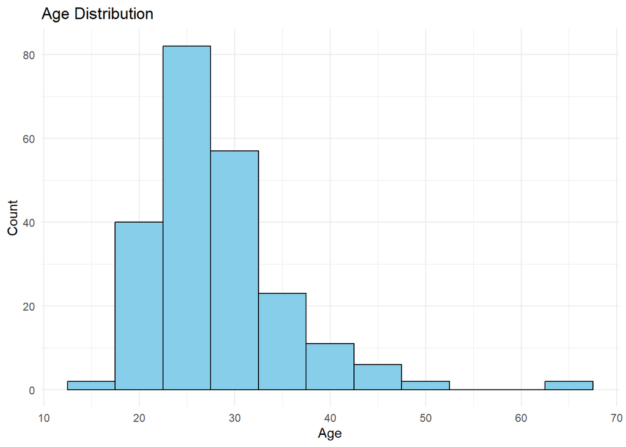

```r
#Histogram for Age
library(ggplot2)
ggplot(stidata, aes(x = A1Age)) +
  geom_histogram(binwidth = 5, fill = "skyblue", color = "black") +
  labs(title = "Age Distribution", x = "Age", y = "Count") +
  theme_minimal()
```

### Interpretation

The histogram shows the age distribution of participants in the study. The majority of individuals fall between 20 and 35 years, with a peak around the 25–30-year age group. This suggests that most respondents are young adults. The number of participants sharply declines after age 35, with very few individuals above 50 years. This right-skewed distribution indicates a younger population dominates the dataset, which may influence the observed patterns in STI prevalence and associated risk behaviors.

```r
table(stidata$Sex.1)
```

```
Female   Male
   108    117
```

```r
# Create frequency table from stidata$Sex.1
t_Sex.1 <- as.data.frame(table(Category = stidata$Sex.1))

# Rename columns
colnames(t_Sex.1) <- c("Category", "Frequency")

# Add percentages
t_Sex.1$Percentage <- round(100 * t_Sex.1$Frequency / sum(t_Sex.1$Frequency), 1)
```

```r
# Prepare data for pie
Sex.1_pie <- t_Sex.1 %>%
  filter(!is.na(Category)) %>%
  mutate(label = paste0(Category, " (", Percentage, "%)"))
```

```r
# Prepare data for pie chart
t_Sex.1 <- stidata %>%
  group_by(Sex.1) %>%
  summarise(Frequency = n()) %>%
  mutate(
    Percentage = round(Frequency / sum(Frequency) * 100, 1),
    Variable = "Sex",
    Category = Sex.1
  ) %>%
  select(Variable, Category, Frequency, Percentage)
```

```r
# Create data for pie chart
Sex.1_pie <- t_Sex.1 %>%
  filter(!is.na(Category)) %>%
  mutate(label = paste0(Category, " (", Percentage, "%)"))
```

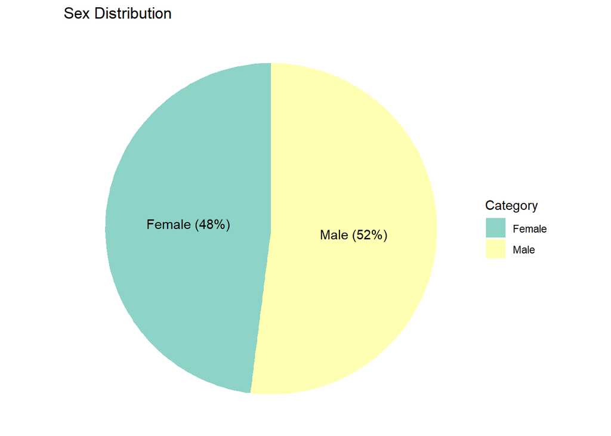

```r
# Plot pie chart
ggplot(Sex.1_pie, aes(x = "", y = Frequency, fill = Category)) +
  geom_bar(width = 1, stat = "identity") +
  coord_polar("y") +
  labs(title = "Sex Distribution") +
  theme_void() +
  geom_text(aes(label = label), position = position_stack(vjust = 0.5)) +
  scale_fill_brewer(palette = "Set3")
```

**Interpretation**

The pie chart shows that 52% of respondents are male and 48% are female. This suggests a nearly equal gender distribution, which supports balanced analysis across sexes.

# 3. Prevalence of sexually transmitted infections (STI case status)

```r
##prevalence of sexually transmitted infections (STI case status)
class(stidata$CaseStatus)
```

```
[1] "integer"
```

```r
table(stidata$CaseStatus)
```

```
  1   2   3
110 113   2
```

```r
stidata<-stidata[order(-stidata$CaseStatus),]
View(stidata[stidata$CaseStatus==3,])
stidata$CaseStatus[stidata$IdNumber==1 & stidata$A1Age==30]=1
stidata$CaseStatus[stidata$IdNumber==31 & stidata$A1Age==23]=1
table(stidata$CaseStatus)
```

```
  1   2
112 113
```

```r
stidata$STI<-NA
stidata$STI[stidata$CaseStatus==1]=1
stidata$STI[stidata$CaseStatus==2]=0
stidata$STI<-factor(stidata$STI,
                                 levels = c(1,0),
                                 labels = c("Positive", "Negative"))
table(stidata$STI)
```

```
Positive Negative
     112      113
```

```r
# Frequency distribution of STI status
prop.table(table(stidata$STI)) * 100
```

```
Positive Negative
49.77778 50.22222
```

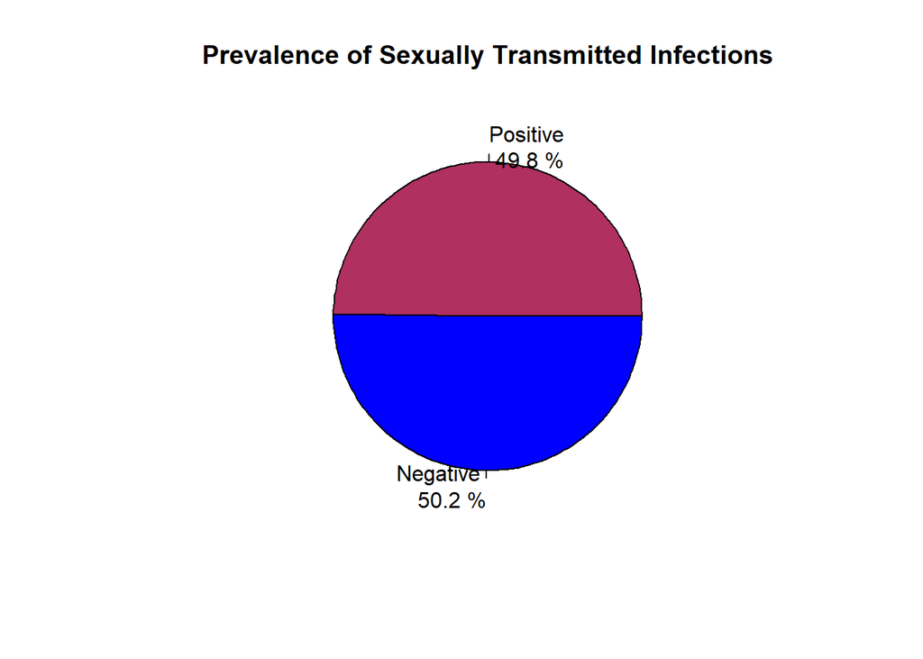

```r
# Pie chart
sti_freq <- table(stidata$STI)

pie(sti_freq,
    col = c("maroon", "blue"),
    main = "Prevalence of Sexually Transmitted Infections",
    labels = paste(names(sti_freq), "\n", round(100 * sti_freq / sum(sti_freq), 1), "%"))
```

**Interpretation**

The prevalence of sexually transmitted infections (STIs) among the study population is approximately 49.8% positive and 50.2% negative. This indicates that STI infection is almost evenly distributed across the sampled individuals. The results highlight the need for robust public health education and prevention programs, as about half of the population is affected

# 4. Association between STI status and other factors

```r
names(stidata)
```

```
 [1] "IdNumber"             "CaseStatus"           "Date"
 [4] "A1Age"                "A2Occupation"         "A3Church"
 [7] "A4LevelOfEducation"   "A5MaritalStatus"      "Weight"
[10] "Height"               "C3StiYesno"           "D1BurialSociety"
[13] "D1religiousgrp"       "D1savingsClub"        "D1tradersAssoc"
[16] "D2Group1"             "D2Group2"             "D3Education"
[19] "D3FuneralAssistance"  "D3HealthServices"     "DurationOfillness"
[22] "E8WhyhaveSTI"         "N10givereceiveforsex" "N11Usedcondom"
[25] "N12UseCondom"         "N13TakenAlcohol"      "N14DoYouHave"
[28] "N15LivingTogether"    "N16HowOldIs"          "D3receivecredit"
[31] "Typeofsti"            "N2SexDebut"           "N3HadAnSti"
[34] "N9Relationship"       "Sex"                  "AgeFirstSex"
[37] "HabitationStatus"     "Unemployed"           "Education"
[40] "AlcoholUse"           "SexPartner1year"      "SexPartner3month"
[43] "LastPartnerSpouse"    "Belong"               "ReceiveHelp"
[46] "SexPartnerLife3"      "Sex.1"                "AgeCat"
[49] "BMI"                  "Occupation"           "Religion"
[52] "Marital_status"       "education_level"      "STI"
```

```r
# Load required packages
library(gtsummary)
library(dplyr)
library(gt)  # for nice display in Viewer
```

```r
# Create Table 2: Sociodemographic Characteristics and STI Status
stidata %>%
  select(STI, Sex.1, AgeCat, Marital_status, education_level, Occupation, Religion) %>%
  tbl_summary(
    by = STI,
    missing = "no",
    percent = "row"
  ) %>%
  add_overall() %>%
  add_p() %>%
  modify_caption("**Table 2: Sociodemographic Characteristics and STI Status**") %>%
  bold_labels() %>%
  as_gt()
```

**Table 2: Sociodemographic Characteristics and STI Status**

| **Characteristic** | **Overall** N = 225<sup>1</sup> | **Positive** N = 112<sup>1</sup> | **Negative** N = 113<sup>1</sup> | **p-value**<sup>2</sup> |
| --- | --- | --- | --- | --- |
| Sex.1 |  |  |  | >0.9 |
| Female | 108 (100%) | 54 (50%) | 54 (50%) |  |
| Male | 117 (100%) | 58 (50%) | 59 (50%) |  |
| AgeCat |  |  |  | 0.5 |
| 16–34 yrs | 193 (100%) | 98 (51%) | 95 (49%) |  |
| 35–64 yrs | 32 (100%) | 14 (44%) | 18 (56%) |  |
| Marital_status |  |  |  | 0.4 |
| Married | 148 (100%) | 73 (49%) | 75 (51%) |  |
| Single | 34 (100%) | 14 (41%) | 20 (59%) |  |
| education_level |  |  |  | 0.5 |
| Primary & Below | 27 (100%) | 15 (56%) | 12 (44%) |  |
| Secondary & Above | 198 (100%) | 97 (49%) | 101 (51%) |  |
| Occupation |  |  |  | 0.050 |
| Employed | 135 (100%) | 60 (44%) | 75 (56%) |  |
| Unemployed | 90 (100%) | 52 (58%) | 38 (42%) |  |
| Religion |  |  |  | 0.4 |
| Belivers | 157 (100%) | 81 (52%) | 76 (48%) |  |
| Non-Belivers | 68 (100%) | 31 (46%) | 37 (54%) |  |

<sup>1</sup> n (%)  
<sup>2</sup> Pearson’s Chi-squared test

**Interpretation:**

Unemployment was significantly associated with STI status (*p = 0.050*), with a higher STI prevalence among the unemployed (58%). Other variables like sex, age, education level, and religion did not show significant associations (all *p > 0.05*).

```r
# Table 3: Social Capital and STI Status
stidata %>%
  select(STI, Belong, ReceiveHelp, D1BurialSociety, D1religiousgrp, D1savingsClub,
         D1tradersAssoc, D3FuneralAssistance, D3receivecredit, D3Education) %>%
  tbl_summary(
    by = STI,
    missing = "no",
    percent = "row"
  ) %>%
  add_overall() %>%
  add_p() %>%
  modify_caption("**Table 3: Social Capital and STI Status**") %>%
  bold_labels() %>%
  as_gt()
```

**Table 3: Social Capital and STI Status**

| **Characteristic** | **Overall** N = 225<sup>1</sup> | **Positive** N = 112<sup>1</sup> | **Negative** N = 113<sup>1</sup> | **p-value**<sup>2</sup> |
| --- | --- | --- | --- | --- |
| Belong | 157 (100%) | 73 (46%) | 84 (54%) | 0.13 |
| ReceiveHelp | 154 (100%) | 69 (45%) | 85 (55%) | 0.028 |
| D1BurialSociety |  |  |  | 0.3 |
| 1 | 77 (100%) | 35 (45%) | 42 (55%) |  |
| 2 | 148 (100%) | 77 (52%) | 71 (48%) |  |
| D1religiousgrp |  |  |  | 0.2 |
| 1 | 123 (100%) | 56 (46%) | 67 (54%) |  |
| 2 | 102 (100%) | 56 (55%) | 46 (45%) |  |
| D1savingsClub |  |  |  | 0.3 |
| 1 | 61 (100%) | 27 (44%) | 34 (56%) |  |
| 2 | 163 (100%) | 84 (52%) | 79 (48%) |  |
| D1tradersAssoc |  |  |  | 0.2 |
| 1 | 12 (100%) | 4 (33%) | 8 (67%) |  |
| 2 | 213 (100%) | 108 (51%) | 105 (49%) |  |
| D3FuneralAssistance |  |  |  | 0.019 |
| 1 | 148 (100%) | 64 (43%) | 84 (57%) |  |
| 2 | 13 (100%) | 10 (77%) | 3 (23%) |  |
| D3receivecredit |  |  |  | 0.6 |
| 1 | 53 (100%) | 26 (49%) | 27 (51%) |  |
| 2 | 108 (100%) | 48 (44%) | 60 (56%) |  |
| D3Education |  |  |  | 0.9 |
| 1 | 34 (100%) | 16 (47%) | 18 (53%) |  |
| 2 | 127 (100%) | 58 (46%) | 69 (54%) |  |

<sup>1</sup> n (%)  
<sup>2</sup> Pearson’s Chi-squared test

**Interpretation:**

Receiving help and funeral assistance were significantly associated with lower STI prevalence (*p = 0.028* and *p = 0.019*, respectively). Other forms of social group involvement did not show significant relationships with STI infection.

```r
# Table 4: Risky Sexual Behavior and STI Status
stidata %>%
  select(STI, N2SexDebut, N10givereceiveforsex, N11Usedcondom, N12UseCondom,
         N13TakenAlcohol, N14DoYouHave, SexPartner1year, SexPartner3month, SexPartnerLife3) %>%
  tbl_summary(
    by = STI,
    missing = "no",
    percent = "row"
  ) %>%
  add_overall() %>%
  add_p() %>%
  modify_caption("**Table 4: Risky Sexual Behavior and STI Status**") %>%
  bold_labels() %>%
  as_gt()
```

**Table 4: Risky Sexual Behavior and STI Status**

| **Characteristic** | **Overall** N = 225<sup>1</sup> | **Positive** N = 112<sup>1</sup> | **Negative** N = 113<sup>1</sup> | **p-value**<sup>2</sup> |
| --- | --- | --- | --- | --- |
| N2SexDebut | 19 (17, 21) | 19 (17, 20) | 20 (17, 21) | 0.13 |
| N10givereceiveforsex |  |  |  | 0.2 |
| 1 yes | 10 (100%) | 7 (70%) | 3 (30%) |  |
| 2 no | 215 (100%) | 105 (49%) | 110 (51%) |  |
| N11Usedcondom |  |  |  | 0.3 |
| 1 yes | 48 (100%) | 21 (44%) | 27 (56%) |  |
| 2 no | 177 (100%) | 91 (51%) | 86 (49%) |  |
| N12UseCondom |  |  |  | 0.13 |
| 1 yes | 32 (100%) | 12 (38%) | 20 (63%) |  |
| 2 no | 193 (100%) | 100 (52%) | 93 (48%) |  |
| N13TakenAlcohol |  |  |  | 0.016 |
| 1 yes | 67 (100%) | 41 (61%) | 26 (39%) |  |
| 2 no | 156 (100%) | 69 (44%) | 87 (56%) |  |
| 3 don't know | 2 (100%) | 2 (100%) | 0 (0%) |  |
| N14DoYouHave |  |  |  | 0.7 |
| 1 | 193 (100%) | 95 (49%) | 98 (51%) |  |
| 2 | 32 (100%) | 17 (53%) | 15 (47%) |  |
| SexPartner1year | 51 (100%) | 41 (80%) | 10 (20%) | <0.001 |
| SexPartner3month | 21 (100%) | 18 (86%) | 3 (14%) | <0.001 |
| SexPartnerLife3 | 91 (100%) | 60 (66%) | 31 (34%) | <0.001 |

<sup>1</sup> Median (Q1, Q3); n (%)  
<sup>2</sup> Wilcoxon rank sum test; Fisher’s exact test; Pearson’s Chi-squared test

**Interpretation:**  
Significant associations were observed between STI status and alcohol use, and having multiple sexual partners in the last 3 months, year, or lifetime (*all p < 0.05*). Condom use and early sexual debut did not show significant associations.